# hw2

Kocherov Roman

Исходные данные По адресу https://raw.githubusercontent.com/SergeyMirvoda/da2016/master/data/calif_penn_2011.csv можно получить набор данных, содержащий информацию о домовладениях в Калифорнии и Пенсильвании за 2011г. Информация сгруппированна по зонам переписи (Census tracts). Загрузка и очистка данных Загрузите данные в датафрейм, который назовите data.

```r
pensilv <- read.csv2("https://raw.githubusercontent.com/SergeyMirvoda/da2016/master/data/calif_penn_2011.csv", header = TRUE, sep = ",")
data<- data.frame(pensilv)
data
```

```
##         X    GEO.id2 STATEFP COUNTYFP TRACTCE POPULATION  LATITUDE
## 1       1 6001400100       6        1  400100       2937 37.859419
## 2       2 6001400200       6        1  400200       1974 37.848292
## 3       3 6001400300       6        1  400300       4865 37.840265
## 4       4 6001400400       6        1  400400       3703 37.848451
## 5       5 6001400500       6        1  400500       3517 37.848941
## 6       6 6001400600       6        1  400600       1571 37.842226
## 7       7 6001400700       6        1  400700       4206 37.841719
## 8       8 6001400800       6        1  400800       3594 37.845393
## 9       9 6001400900       6        1  400900       2302 37.839285
## 10     10 6001401000       6        1  401000       5678 37.831263
## 11     11 6001401100       6        1  401100       4156 37.829959
## 12     12 6001401200       6        1  401200       2416 37.830988
## 13     13 6001401300       6        1  401300       3528   37.8165
## 14     14 6001401400       6        1  401400       4314 37.819904
```

[output cut: 26464 more lines]

Сколько строк и столбцов в data?

```r
nrow(data)
```

```
## [1] 11275
```

```r
ncol(data)
```

```
## [1] 34
```

Выполните следующую команду и объясните, что она делает. colSums(apply(data,c(1,2), is.na))

```r
colSums(apply(data,c(1,2), is.na))
```

```
##                           X                     GEO.id2
##                           0                           0
##                     STATEFP                    COUNTYFP
##                           0                           0
##                     TRACTCE                  POPULATION
##                           0                           0
##                    LATITUDE                   LONGITUDE
##                           0                           0
##           GEO.display.label          Median_house_value
##                           0                         599
##                 Total_units                Vacant_units
##                           0                           0
##                Median_rooms  Mean_household_size_owners
##                         157                         215
## Mean_household_size_renters         Built_2005_or_later
##                         152                          98
##          Built_2000_to_2004                 Built_1990s
##                          98                          98
##                 Built_1980s                 Built_1970s
##                          98                          98
##                 Built_1960s                 Built_1950s
##                          98                          98
##                 Built_1940s       Built_1939_or_earlier
##                          98                          98
##                  Bedrooms_0                  Bedrooms_1
##                          98                          98
##                  Bedrooms_2                  Bedrooms_3
##                          98                          98
##                  Bedrooms_4          Bedrooms_5_or_more
##                          98                          98
##                      Owners                     Renters
##                         100                         100
##     Median_household_income       Mean_household_income
##                         115                         126
```

Функция colSums выдает сумму по колонкам, функция apply имеет такие атрибуты, как data - наш массив данных, c(1,2)- проход по всем колонкам и строкам, is.na - поднимает флаг TRUE, если текущее знаечние отсутствует(NA). Функция na.omit() принимает датафрейм и возвращает новый датафрейм, игнорируя строки, содержащие значение NA. Используйте эту функцию для удаления строк с неполными данными.

```r
strings<-nrow(data)
data<-na.omit(data)
```

Сколько строк было удалено?

```r
strings-nrow(data)
```

```
## [1] 670
```

Соответствует ли результат выполнения, значениям из пункта 3? Результаты отличаются, т.к. в одной строке может быть несколько пустых клеток. Новые дома Переменная(колонка) Built_2005_or_later содержит данные о проценте домов, построенных с 2005 года. Постройте диаграмму рассеяния (scatterplot) медианы стоимости домов (переменная Median_house_value) относительно процента новых домов.

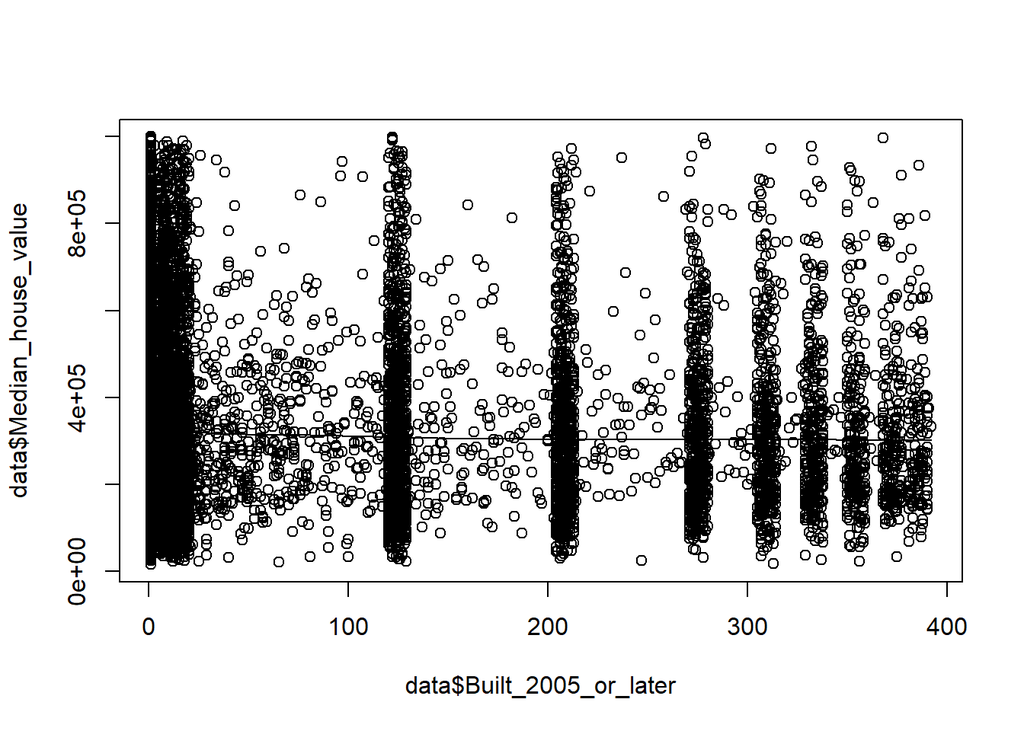

```r
scatter.smooth(data$Built_2005_or_later, data$Median_house_value)
```

Постройте ещё два графика для каждого из штатов отдельно. Номер штата содержится в переменной (STATEFP), где Калифорния 6-й штат, а Пенсильвания 42.

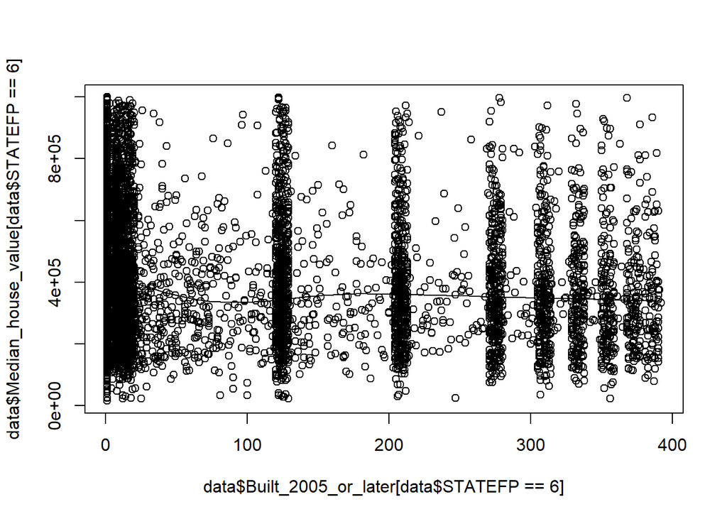

```r
scatter.smooth(data$Built_2005_or_later[data$STATEFP==6], data$Median_house_value[data$STATEFP==6])
```

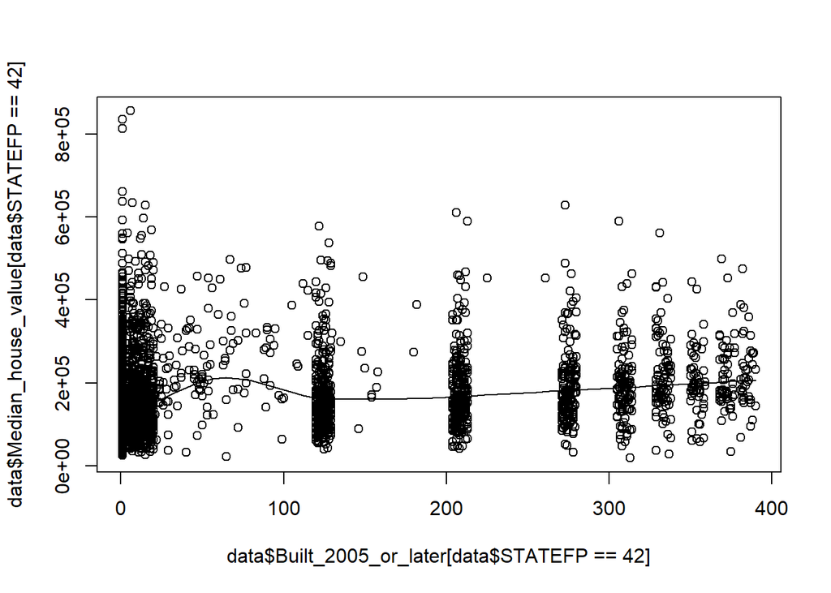

```r
scatter.smooth(data$Built_2005_or_later[data$STATEFP==42], data$Median_house_value[data$STATEFP==42])
```

Незанятые дома Уровень найма (vacancy rate) — доля домов, которые не были заняты. В данных содержатся колонки, содержащие общее количество домовладений и количество не занятых домовладений.

В датафрейм data добавьте новую колонку vacancy_rate, которая должна содержать вышеописанный показатель.

```r
data$vacancy_rate<-data$Vacant_units / data$Total_units
```

Найдите минимум, максимум, среднее и медиану полученных значений показателя.

```r
min(data$vacancy_rate)
```

```
## [1] 0
```

```r
max(data$vacancy_rate)
```

```
## [1] 0.965311
```

```r
median(data$vacancy_rate)
```

```
## [1] 0.06767283
```

```r
mean(data$vacancy_rate)
```

```
## [1] 0.08888789
```

Постройте диаграмму уровня найма относительно медианы стоимости домов. Что можно заметить?

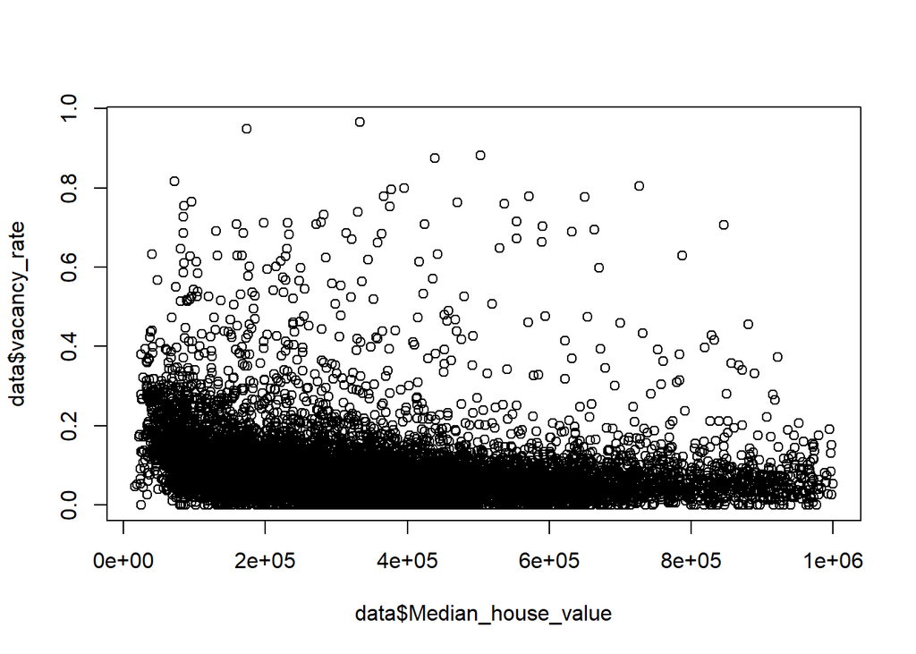

```r
plot(data$Median_house_value, data$vacancy_rate)
```

```r
acc <- c()
for (tract in 1:nrow(data)) {
  if (data$STATEFP[tract] == 6) {
    if (data$COUNTYFP[tract] == 1) {
      acc <- c(acc, tract)
    }
  }
}
accmv <- c()
for (tract in acc) {
  accmv <- c(accmv, data[tract,10])
}
median(accmv)
```

```
## [1] 474050
```

Сперва добавляем в acc номера строк с номером 6(Калифорния) и городом номер 1 Аламеда, затем заполняем вектор accmv значением из колонки Median_house_value, по строчкам acc, и считаем медиану в полученном векторе accmv. Напишите другим способом в одну строку, то же самое, что делает нижеуказанный код. Способов получить тот же ответ множество, достаточно одного.

```r
median(data$Median_house_value[data$STATEFP==6][data$COUNTYFP==1],na.rm=TRUE)
```

```
## [1] 474050
```

Найдите средний процент построенных домовладений в округах (Butte County, Santa Clara, York County) Butte County, Santa Clara расположены в Калифорнии, поэтому чтобы посчитать процент относительно штата необходимо сделать отбор данных

```r
California <- data$STATEFP == 6
totalHousesCalifornia <- sum(data$Total_units[California])
ButteCounty <- data$COUNTYFP == 7
mean(data$Total_units[California & ButteCounty]/totalHousesCalifornia, na.rm = TRUE)
```

```
## [1] 0.0001458294
```

```r
SantaClara <- data$COUNTYFP == 85
mean(data$Total_units[California & SantaClara]/totalHousesCalifornia, na.rm = TRUE)
```

```
## [1] 0.0001320997
```

Аналогично для York County в Pensilvania

```r
Pensy <- data$STATEFP == 42
totalHousesPensy <- sum(data$Total_units[Pensy])
YorkCounty <- data$COUNTYFP == 133
mean(data$Total_units[Pensy & YorkCounty]/totalHousesPensy, na.rm = TRUE)
```

```
## [1] 0.000360114
```

Функция cor рассчитывает коэффициент корреляции между двумя переменными. Рассчитайте корреляцию между медианы стоимости домовладений (Median_house_value) и процентом построенных домов (Built_2005_or_later): для всего набора данных

```r
cor(as.numeric(data$Built_2005_or_later), data$Median_house_value)
```

```
## [1] -0.06329452
```

для Калифорнии

```r
cor(as.numeric(data$Built_2005_or_later[California]), data$Median_house_value[California])
```

```
## [1] -0.144982
```

для Пенсильвании

```r
cor(as.numeric(data$Built_2005_or_later[Pensy]), data$Median_house_value[Pensy])
```

```
## [1] 0.194826
```

для округа Butte County

```r
cor(as.numeric(data$Built_2005_or_later[California & ButteCounty]), data$Median_house_value[California & ButteCounty],use = "pairwise.complete.obs")
```

```
## [1] 0.09716529
```

для округа Santa Clara

```r
cor(as.numeric(data$Built_2005_or_later[California & SantaClara]), data$Median_house_value[California & SantaClara],use = "pairwise.complete.obs")
```

```
## [1] -0.03273144
```

для округа York County

```r
cor(as.numeric(data$Built_2005_or_later[Pensy & YorkCounty]), data$Median_house_value[Pensy & YorkCounty],use = "pairwise.complete.obs")
```

```
## [1] 0.3561032
```

Постройте три диаграммы медианы стоимости домовладений (Median_house_value) относительно медианы дохода (Median_household_income) для трёх округов. Допустимо указать все три на одном графике.

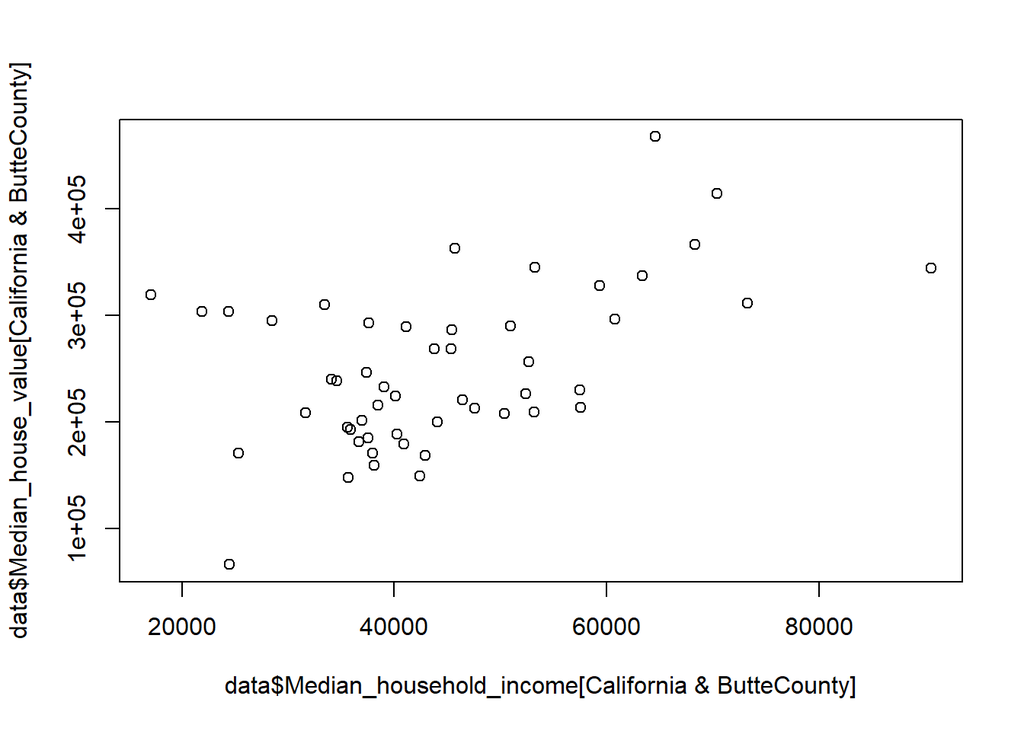

```r
plot(
  data$Median_house_value[California & ButteCounty] ~ data$Median_household_income[California & ButteCounty])
```

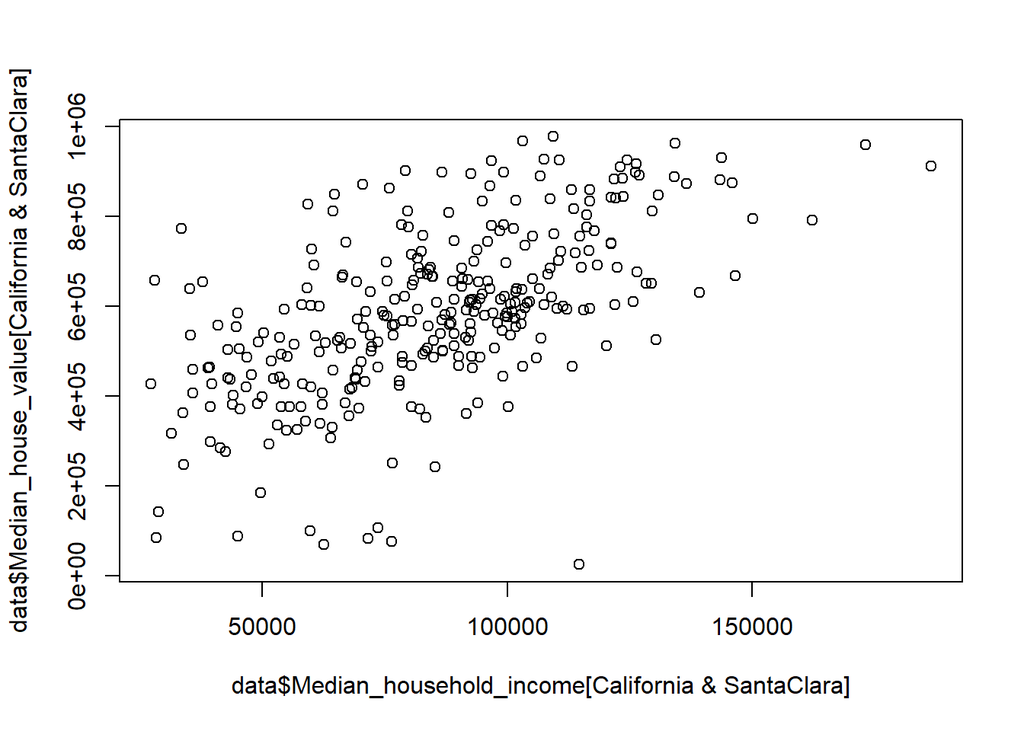

```r
plot(
  data$Median_house_value[California & SantaClara] ~ data$Median_household_income[California & SantaClara])
```

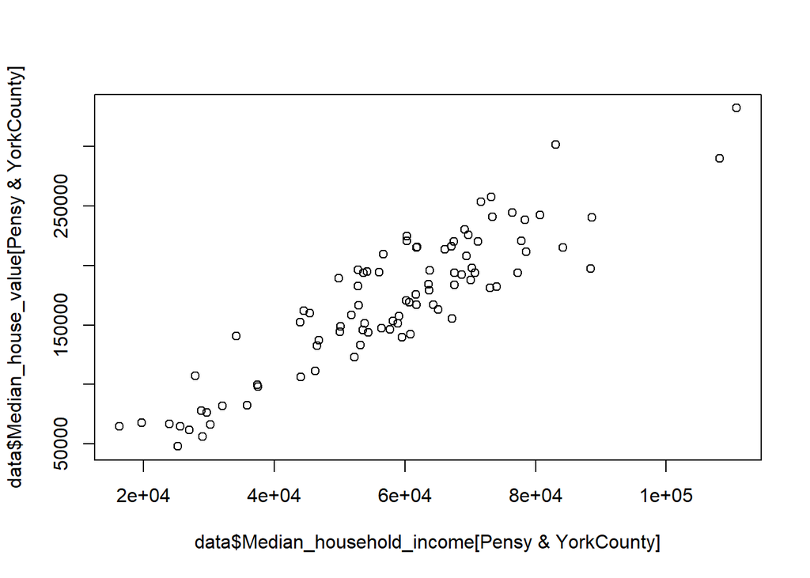

```r
plot(
  data$Median_house_value[Pensy & YorkCounty] ~ data$Median_household_income[Pensy & YorkCounty])
```